# Lecture 17: Independent t-test

Data Analysis for Psychology in R 1

Tom Booth

Click for slides

## Today

- Discuss in detail independent sample $t$-tests
  - When to use
  - Tested hypotheses
  - Calculation
  - Doing in R
  - Write up
- $t$-test assumptions

## Purpose & Data

- The independent or Student’s $t$-test is used when we want to test the difference in mean between two measured groups.
- The groups must be independent:
  - No person can be in both groups.
- Examples:
  - Treatment versus control group in an experimental study.
  - Married versus not married
- Data Requirements
  - A continuously measured variable.
  - A binary variable denoting groups

## Hypotheses

- Identical to one-sample, only now we are comparing two measured groups.
- Two-tailed:

$$\begin{matrix}
H_0: \mu_1 = \mu_2 \\
H_1: \mu_1 \neq \mu_2
\end{matrix}$$

- One-tailed:

$$\begin{matrix}
H_0: \mu_1 = \mu_2 \\
H_1: \mu_1 < \mu_2 \\
H_1: \mu_1 > \mu_2
\end{matrix}$$

## Example

- Example taken from Howell, D.C. (2010). *Statistical Methods for Psychology, 7th Edition*. Belmont, CA: Wadsworth Cengage Learning.
- Data from Aronson, Lustina , Good, Keough , Steele and Brown (1998). Experiment on stereotype threat.
  - Two independent groups college students (n=12 control; n=11 threat condition).
  - Both samples excel in maths.
  - Threat group told certain students usually do better in the test

## Data

| Group | Score |
| --- | --- |
| Threat | 7 |
| Threat | 5 |
| Threat | 6 |
| Threat | 5 |
| Control | 10 |
| Control | 11 |
| Control | 8 |
| Control | 9 |

## Visualizing data

- We spoke earlier in the course about the importance of visualizing our data.
- Here, we want to show the mean and distribution of scores by group.
- So we want a…..

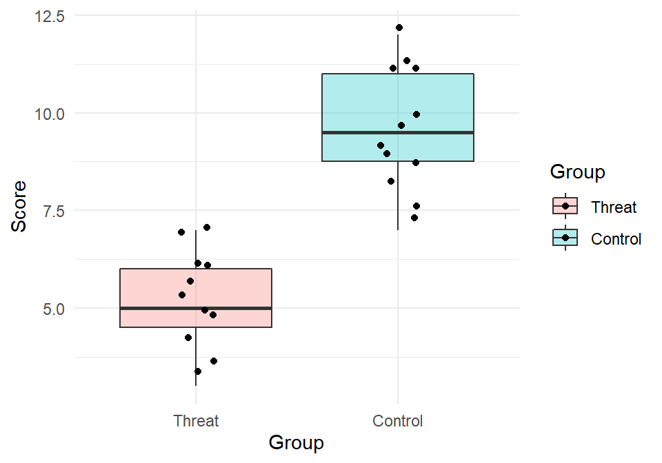

```r
ggplot(data = threat, aes(x = Group, y = Score, fill = Group)) +
  geom_boxplot(alpha = 0.3) +
  geom_jitter(width = 0.1)+
  theme_minimal()
```

- My hypothesis is that the threat group will perform worse than the control group.
  - This is a one-tailed, or directional hypothesis.
- And I will use an alpha = .05

## t-statistic

$$t = \frac{\bar{x}_1 - \bar{x}_2}{SE(\bar{x}_1 - \bar{x}_2)}$$

- Where
  - $\bar{x}_1$ and $\bar{x}_2$ are the sample means in each group
  - $SE(\bar{x}_1 - \bar{x}_2)$ is standard error of the difference
- Sampling distribution is a $t$-distribution with $n-2$ degrees of freedom.

## Standard Error Difference

- First calculate the pooled standard deviation.

$$S_p = \sqrt\frac{(n_1 - 1)s_1^2 + (n_2 - 1)s_2^2}{n_1 + n_2 - 2}$$

- Then use this to calculate the SE of the difference.

$$SE(\bar{x}_1 - \bar{x}_2) = S_p \sqrt{\frac{1}{n_1} + \frac{1}{n_2}}$$

## Calculation

- Steps in my calculations:
  - Calculate the sample mean in both groups.
  - Calculate the pooled SD.
  - Check I know my n.
  - Calculate the standard error.
  - Use all this to calculate $t$.

```r
calc <- threat %>%
  group_by(Group) %>%
  summarise(
    Mean = round(mean(Score),2),
    SD = round(sd(Score),2),
    N = n()
  )
```

```
# A tibble: 2 x 4
  Group    Mean    SD     N
  <fct>   <dbl> <dbl> <int>
1 Threat   5.27  1.27    11
2 Control  9.58  1.51    12
```

```
# A tibble: 2 x 4
  Group    Mean    SD     N
  <fct>   <dbl> <dbl> <int>
1 Threat   5.27  1.27    11
2 Control  9.58  1.51    12
```

- Calculate pooled standard deviation

$$S_p = \sqrt\frac{(n_1 - 1)s_1^2 + n_2 - 1)s_2^2}{n_1 + n_2 - 2} = \sqrt{\frac{10*1.27 + 11*1.51}{11+12-2}} = \sqrt{\frac{29.31}{21}} = 1.396$$

- Calculate pooled standard deviation

$$S_p = \sqrt\frac{(n_1 - 1)s_1^2 + n_2 - 1)s_2^2}{n_1 + n_2 - 2} = \sqrt{\frac{10*1.27 + 11*1.51}{11+12-2}} = \sqrt{\frac{29.31}{21}} = 1.396$$

- Calculate the standard error.

$$SE(\bar{x}_1 - \bar{x}_2) = S_p \sqrt{\frac{1}{n_1} + \frac{1}{n_2}} = 1.396\sqrt{\frac{1}{11}+\frac{1}{12}} = 1.396*0.417 = 0.583$$

- Use all this to calculate $t$.

$$t = \frac{\bar{x}_1 - \bar{x}_2}{SE(\bar{x}_1 - \bar{x}_2)} = \frac{5.27-9.58}{0.583} = -7.39$$

- Note: There is a small amount of rounding error when we compare to $t$ calculated in R.
  - Actual value = -7.38

## Is my test significant?

- Steps:
  - Calculate my degrees of freedom $n-2 = 23-2 = 21$
  - Check my value of $t$ against the $t$-distribution with the appropriate df and make my decision

## Is our test significant?

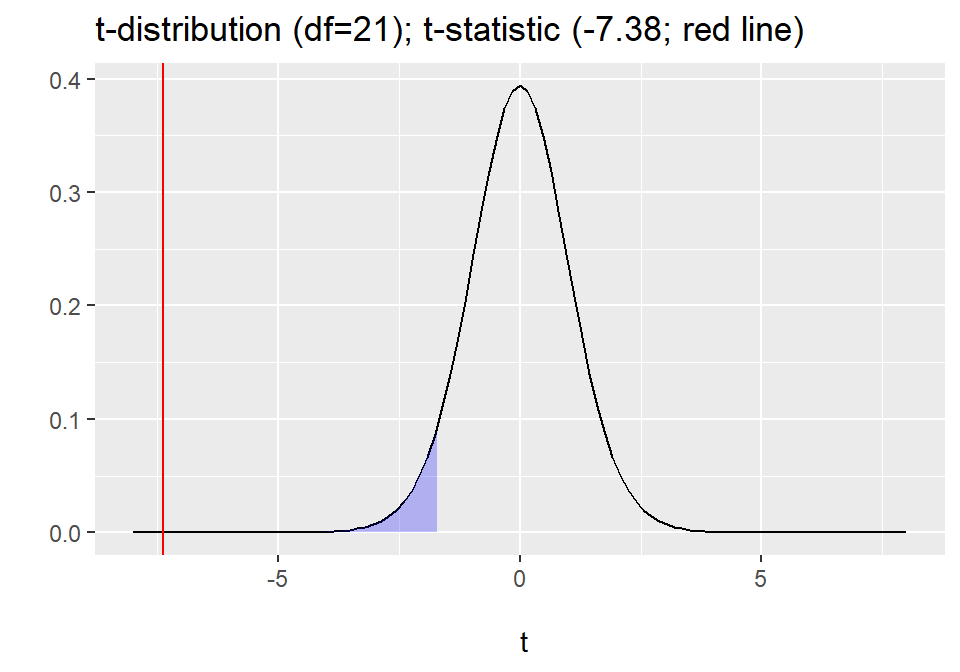

```r
tibble(
  LowerCrit = round(qt(0.05, 21),2)
)
# A tibble: 1 x 1
  LowerCrit
      <dbl>
1     -1.72
```

## In R

```r
res <- t.test(Score ~ Group,
       var.equal = TRUE,
       alternative = "less",
       data = threat)
```

```
    Two Sample t-test

data:  Score by Group
t = -7.3817, df = 21, p-value = 1.458e-07
alternative hypothesis: true difference in means is less than 0
95 percent confidence interval:
      -Inf -3.305768
sample estimates:
 mean in group Threat mean in group Control
             5.272727              9.583333
```

## Exact p-values

```r
tibble(
  Exactp = 1-pt(7.3817, 21)
)
# A tibble: 1 x 1
       Exactp
        <dbl>
1 0.000000146
```

## Write up

An independent sample $t$-test was used to assess whether the maths score mean of the control group (12) was higher than that of the stereotype threat group (11). There was a significant difference in test score between the control (Mean=9.58; SD=1.51) and threat (Mean=5.27; SD=1.27) groups ($t$(21)=-7.38, $p$< .05, one-tailed). Therefore, we reject the null hypothesis. The direction of effect supports our directional hypothesis and indicates that the threat group performed more poorly than the control group.

## Assumptions

- The independent sample $t$-test has the following assumptions:
  - Independence of observations within and across groups.
  - Continuous variable is approximately normally distribution **within both groups**.
    - Equivalently, that the difference in means is normally distributed.
  - Homogeneity of variance across groups.

## Assumption checks summary

|  | Description | One-Sample t-test | Independent Sample t-test | Paired Sample t-test |
| --- | --- | --- | --- | --- |
| Normality | Continuous variable (and difference) is normally distributed. | Yes (Population) | Yes (Both groups/ Difference) | Yes (Both groups/ Difference) |
| Tests: | Descriptive Statistics; Shapiro-Wilks Test; QQ-plot |  |  |  |
| Independence | Observations are sampled independently. | Yes | Yes (within and across groups) | Yes (within groups) |
| Tests: | None. Design issue. |  |  |  |
| Homogeneity of variance | Population level standard deviation is the same in both groups. | NA | Yes | Yes |
| Tests: | F-test |  |  |  |
| Matched Pairs in data | For paired sample, each observation must have matched pair. | NA | NA | Yes |
| Tests: | None. Data structure issue. |  |  |  |

## Assumption checks: Normality

- Descriptive statistics:
  - Skew: No strict cuts for skew.
    - Skew < |1| generally not problematic
    - |1| < skew > |2| slight concern
    - Skew > |2| investigate impact

## Histograms

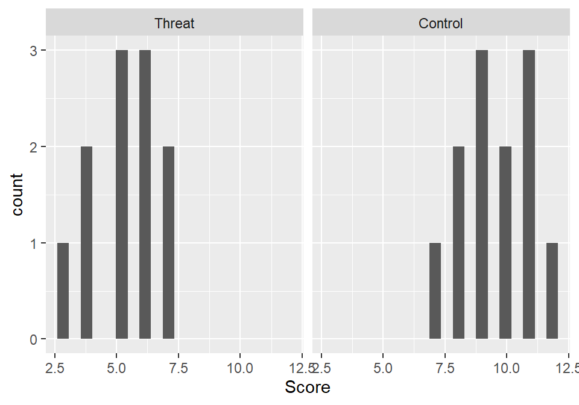

```r
threat %>%
  ggplot(., aes(x=Score)) +
  geom_histogram(bins = 20) +
  facet_wrap(~ Group)
```

## Skew

```r
library(moments)
threat %>%
  group_by(Group) %>%
  summarise(
    skew = round(skewness(Score),2)
  )
# A tibble: 2 x 2
  Group    skew
  <fct>   <dbl>
1 Threat  -0.23
2 Control -0.08
```

- QQ-plots:
  - Plots the sorted quantiles of one data set (distribution) against sorted quantiles of data set (distribution).
  - Quantile = the percent of points falling below a given value.
  - For a normality check, we can compare our own data to data drawn from a normal distribution

## QQ-plots

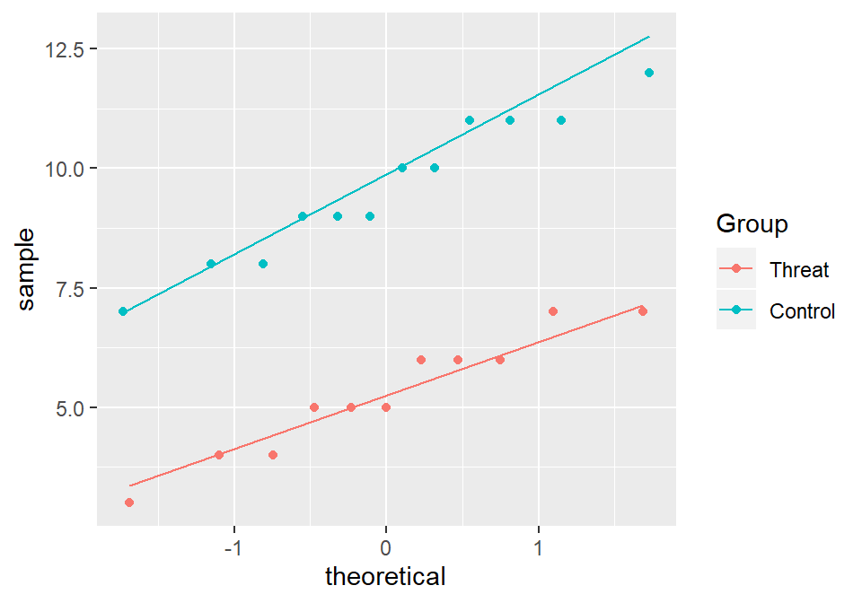

```r
threat %>%
  ggplot(., aes(sample = Score, colour = Group)) +
  stat_qq() +
  stat_qq_line()
```

- Shapiro-Wilks test:
  - Checks properties of the observed data against properties we would expected from normally distributed data.
  - Statistical test of normality.
  - $H_0$: data = a normal distribution.
  - $p$-value $< \alpha$ = reject the null, data are not normal.
    - Sensitive to N as all p-values will be.
    - In very large N, normality should also be checked with QQ-plots alongside statistical test.

## Shapiro-Wilks R

```r
con <- threat %>% filter(Group == "Control") %>% select(Score)
shapiro.test(con$Score)

    Shapiro-Wilk normality test

data:  con$Score
W = 0.95538, p-value = 0.7164
```

```r
thr <- threat %>% filter(Group == "Threat") %>% select(Score)
shapiro.test(thr$Score)

    Shapiro-Wilk normality test

data:  thr$Score
W = 0.93979, p-value = 0.518
```

## Assumption checks: Homogeneity of variance

- Levene’s test:
  - Statistical test for the equality (or homogeneity) of variances across groups.
  - Test statistic is essentially a ratio of variance estimates calculated based on group means versus grand mean.
  - $H_0$: Population variances are equal.
  - $p$-value $< \alpha$ = reject the null, the variances differ across groups.

## F-test R

```r
var.test(threat$Score ~ threat$Group, ratio = 1, conf.level = 0.95)

    F test to compare two variances

data:  threat$Score by threat$Group
F = 0.71438, num df = 10, denom df = 11, p-value = 0.6038
alternative hypothesis: true ratio of variances is not equal to 1
95 percent confidence interval:
 0.2026227 2.6181459
sample estimates:
ratio of variances
         0.7143813
```

## Violation of homogeneity of variance

- If the variances differ, we can use a Welch test.
- Conceptually very similar, but we do not use a pooled standard deviation.
  - As such our estimate of the SE of the difference changes
  - As do our degrees of freedom

## Welch test

- If the variances differ, we can use a Welch test.
- Test statistic = same
- SE calculation:

$$SE(\bar{x}_1 - \bar{x}_2) = \sqrt{\frac{s_1^2}{n_1} + \frac{s_2^2}{n_2}}$$

- And degrees of freedom (don’t worry, not tested)

$$df = \frac{(\frac{s_1^2}{n_1} + \frac{s_2^2}{n_2})^2}{\frac{(\frac{s_1^2}{n_1})^2}{n_1 -1} + \frac{(\frac{s_2^2}{n_2})^2}{n_2 -1}}$$

## Welch in R

```r
welch <- t.test(Score ~ Group,
       var.equal = FALSE, #default, only here to highlight difference
       alternative = "less",
       data = threat)
```

```r
welch

    Welch Two Sample t-test

data:  Score by Group
t = -7.4379, df = 20.878, p-value = 1.346e-07
alternative hypothesis: true difference in means is less than 0
95 percent confidence interval:
      -Inf -3.313093
sample estimates:
 mean in group Threat mean in group Control
             5.272727              9.583333
```

## A comment on sample size

- In class we have been using examples with very small N.
  - This is purely so we can show working on slides etc.
- Typically, even with simple tests like we have discussed so far, with n ~20, you should think carefully about whether statistical analyses are appropriate.

## Tasks for this week…

1. Finish tasks from last week.
2. Quiz 17: One-sample $t$-tests
   - Today at 17:00.
   - Close Monday 3rd at 17:00